# Bayesian data analysis & cognitive modeling

\[ \definecolor{firebrick}{RGB}{178,34,34} \newcommand{\red}[1]{{\color{firebrick}{#1}}} \] \[ \definecolor{mygray}{RGB}{178,34,34} \newcommand{\mygray}[1]{{\color{mygray}{#1}}} \] \[ \newcommand{\set}[1]{\{#1\}} \] \[ \newcommand{\tuple}[1]{\langle#1\rangle} \] \[\newcommand{\States}{{T}}\] \[\newcommand{\state}{{t}}\] \[\newcommand{\pow}[1]{{\mathcal{P}(#1)}}\]

## roadmap

- JAGS
  - background
  - model specification syntax
  - workflow
  - tips & tricks

## recap

Bayes rule for data analysis:

\[\underbrace{P(\theta \, | \, D)}_{posterior} \propto \underbrace{P(\theta)}_{prior} \times \underbrace{P(D \, | \, \theta)}_{likelihood}\]

normalizing constant:

\[ \int P(\theta') \times P(D \mid \theta') \, \text{d}\theta' = P(D) \]

easy to solve only if:

- \(\theta\) is a single discrete variable with reasonably sized domain
- \(P(\theta)\) is conjugate prior for the likelihood function \(P(D \mid \theta)\)
- we are very lucky

## recap

Markov Chain Monte Carlo

get sequence of samples \(x_1, \dots, x_n\) s.t.

1. sequence has the Markov property (\(x_{i+1}\) depends only on \(x_i\)), and
2. the stationary distribution of the chain is \(P\).

MCMC algorithms

- Metropolis Hastings
  - versatile but often inefficient
  - depends on proposal distribution
- Gibbs sampling
  - fast and efficient, but not universally applicable
  - depends on availability of conditional posterior

## recap

assessing quality of sample chains

- convergence / representativeness
  - trace plots
  - \(\hat{R}\)
- efficiency
  - autocorrelation
  - effective sample size

## JAGS

## history

BUGS project (1989 - present ???)

- Bayesian inference Using Gibbs Sampling
- developed by UK-based biostatisticians

[WinBUGS](http://www.mrc-bsu.cam.ac.uk/software/bugs/) (1997 - 2007)

- Windows based; with GUI
- component pascal

[OpenBUGS](http://openbugs.net/w/FrontPage) (2005 - present)

- Windows & Linux; MacOS through [Wine](https://www.winehq.org)
- component pascal

[JAGS](http://mcmc-jags.sourceforge.net) (2007 - present)

- Windows, Linux, MacOS
- no GUI
- written in C++

## JAGS

Just Another Gibbs Sampler

- declarative language
  - model as a directed acyclic graph
  - nodes are variables, edges are deterministic or probabilistic dependencies
- automatically selects adequate sampler
- call from & process output in R via packages:
  - `R2Jags`, `rjags` …

coded by [Martyn Plummer](https://www.iarc.fr/en/staffdirectory/displaystaff.php?id=10118)

## example

```r
require('rjags') # also loads `coda` package
modelString = "
model{
  theta ~ dbeta(1,1)
  k ~ dbinom(theta, N)
}"
# prepare for JAGS
dataList = list(k = 7, N = 24)
# set up and run model
jagsModel = jags.model(file = textConnection(modelString),
                       data = dataList,
                       n.chains = 2)
update(jagsModel, n.iter = 5000)
codaSamples = coda.samples(jagsModel,
                           variable.names = c("theta"),
                           n.iter = 5000)
```

## example

```r
ms = ggmcmc::ggs(codaSamples)
ms %>% group_by(Parameter) %>%
   summarise(mean = mean(value),
             HDIlow  = coda::HPDinterval(as.mcmc(value))[1],
             HDIhigh = coda::HPDinterval(as.mcmc(value))[2])
```

```
## # A tibble: 1 × 4
##   Parameter      mean    HDIlow   HDIhigh
##      <fctr>     <dbl>     <dbl>     <dbl>
## 1     theta 0.3087857 0.1436357 0.4823556
```

## example

```r
  tracePlot = ggmcmc::ggs_traceplot(ms)
  densPlot = ggmcmc::ggs_density(ms) +
    stat_function(fun = function(x) dbeta(x, 8,18), color = "black")
```

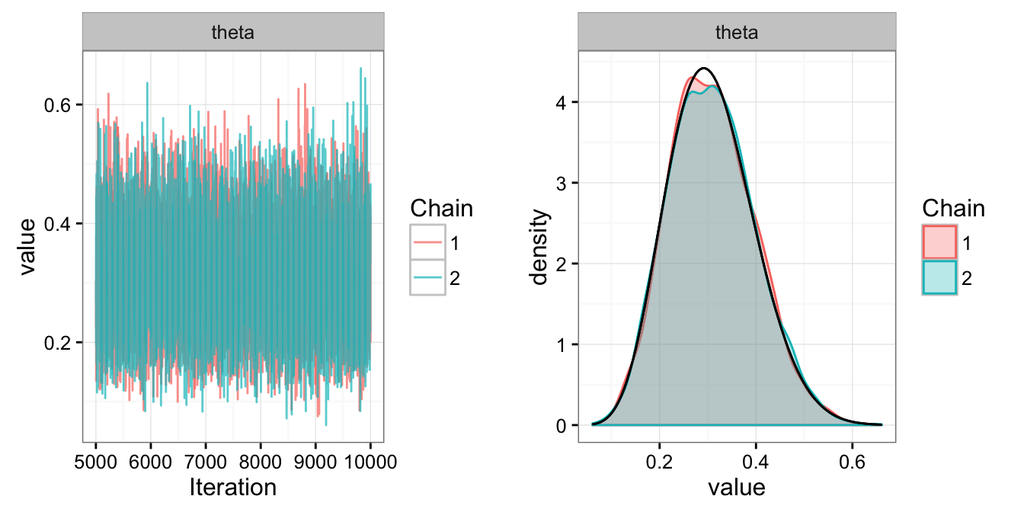

```r
  gridExtra::grid.arrange(tracePlot, densPlot, ncol = 2)
```

## Using JAGS

## about JAGS

- current version 4
  - faster, allows for use of `=`
  - added samplers and distributions (not yet all documented!?)
- syntax is a mix of BUGS and R
  - careful with parameterization of probability distributions !!!
- declarative model specification
  - directed acyclic graphs / Bayes nets
    - nodes are variables, edges are dependencies
  - order invariant
  - no variable reassignment, no control flow statements etc.
    - exception: `ifelse`, `step` … commands for boolean switching
    - `for` loops for vector construction
- \(\exists\) command-line interface (not used in this course)

## structure of a JAGS model description

```r
# declare size of variables if needed
var ... ;
# do some data massaging (usually done in R)
data{
  ...
}
# specify model
model{
  ...
}
```

- you could write this into a separtate file called "myModel.jags.R"
  - this is untidy file naming but gives you default R syntax highlighting

## (nonsense) example

```r
var myData[5,100], myMu[5], myTau[5];
data{
  N = sum(counts) # counts is input to JAGS from R
  indVector = c(3,2,4) # works like in R
  specialConditions = counts[indVector] # like R; new in JAGS 4
}
model{
  for (i in 1:dim(myData)[1]){
    for (j in 1:dim(myData)[2]){
      myData[i,j] ~ dnorm(myMu[i], myTau[i])
    }
  }
  for (i in 1:5){
    tmp[i] ~ dbeta(1,1)
    myMu[i] = 100 + tmp[i] - 0.5
    myTau[i] ~ dunif(0, 1000)
  }
}
```

## caveats

- semicolon after declaration of variable dimensions
- declare dimensions to avoid confusing the JAGS compiler
- JAGS error messages are occassionally underinformative
- all model specification lines are probabilistic ("~") or deterministic ("=" or "<-")
  - "=" only works for JAGS 4+
- all probabilistic dependencies must be samples from a distribution known to JAGS!
  - this is therefore all ruled out:

```r
  x ~ dbeta(1,1) - 0.5

  myCostumDistribution = ... # something fancy
  x ~ myCustomDistribution(0,1)
```

## another example

Your turn: what's this model good for?

- `obs` is a vector of 100 observations (real numbers)

```r
model{
  mu ~ dunif(-2,2)
  var ~ dunif(0, 100)
  tau = 1/var
  for (i in 1:100){
    obs[i] ~ dnorm(mu,tau)
  }
}
```

NB: JAGS uses precision \(\tau = 1/\sigma^2\), not standard deviation \(\sigma\) in `dnorm`

## model specifications, formally

```r
model{
  mu ~ dunif(-2,2)
  var ~ dunif(0, 100)
  tau = 1/var
  for (i in 1:100){
    obs[i] ~ dnorm(mu,tau)
  }
}
```

\[\mu \sim \text{Unif}(-2,2)\] \[\sigma^2 \sim \text{Unif}(0,100)\] \[obs_i \sim \text{Norm}(\mu, \sigma)\]

## running a JAGS script

## homebrew MH samples

```r
set.seed(1789)

fakeData = rnorm(200, mean = 0, sd = 1)

f = function(mu, sigma){
  if (sigma <=0){
    return(0)
  }
  priorMu = dunif(mu, min = -4, max = 4)
  priorSigma = dunif(sigma, min = 0, max = 4)
  likelihood =  prod(dnorm(fakeData, mean = mu, sd = sigma))
  return(priorMu * priorSigma * likelihood)
}

samplesMH = MH(f,
               iterations = 60000,
               chains = 2,
               burnIn = 10000) # outputs mcmc.list from `coda` package
```

## back to the future

```r
modelString = "
model{
  mu ~ dunif(-4,4)
  sigma ~ dunif(0,4)
  tau = 1/sigma^2
  for (i in 1:length(obs)){
    obs[i] ~ dnorm(mu,tau)
  }
}"
jagsModel = jags.model(file = textConnection(modelString),
                       data = list(obs = fakeData),
                       n.chains = 2)
update(jagsModel, n.iter = 5000)
samplesJAGS = coda.samples(jagsModel,
                           variable.names = c("mu", "sigma"),
                           n.iter = 5000)
```

## compare sample outputs

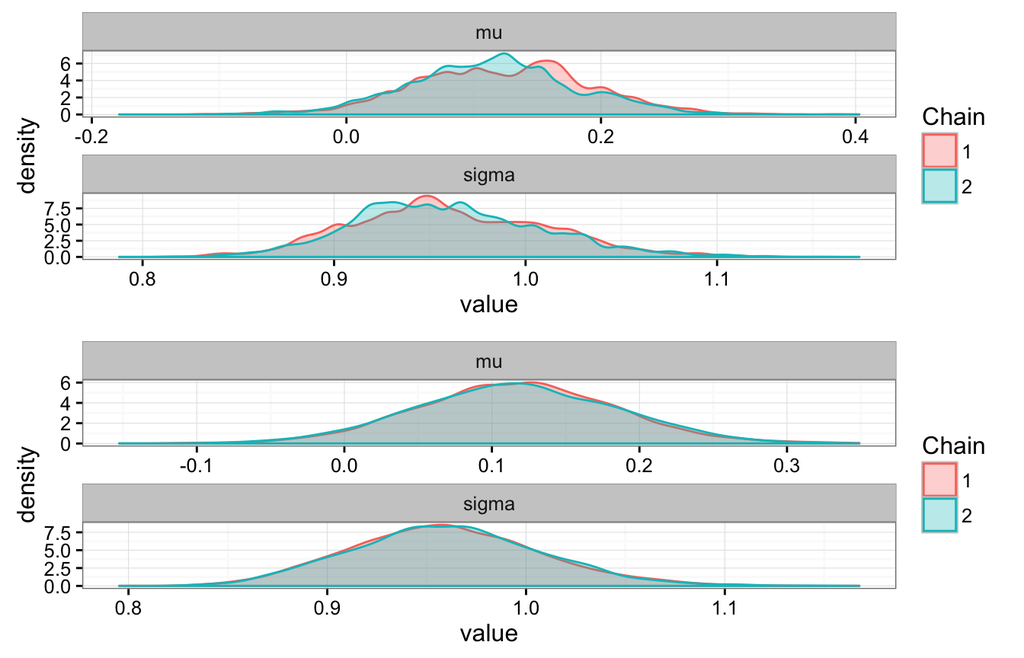

```r
grid.arrange(ggs_density(ggs(samplesMH)) ,       ggs_density(ggs(samplesJAGS)) )
```

## compare sample outputs

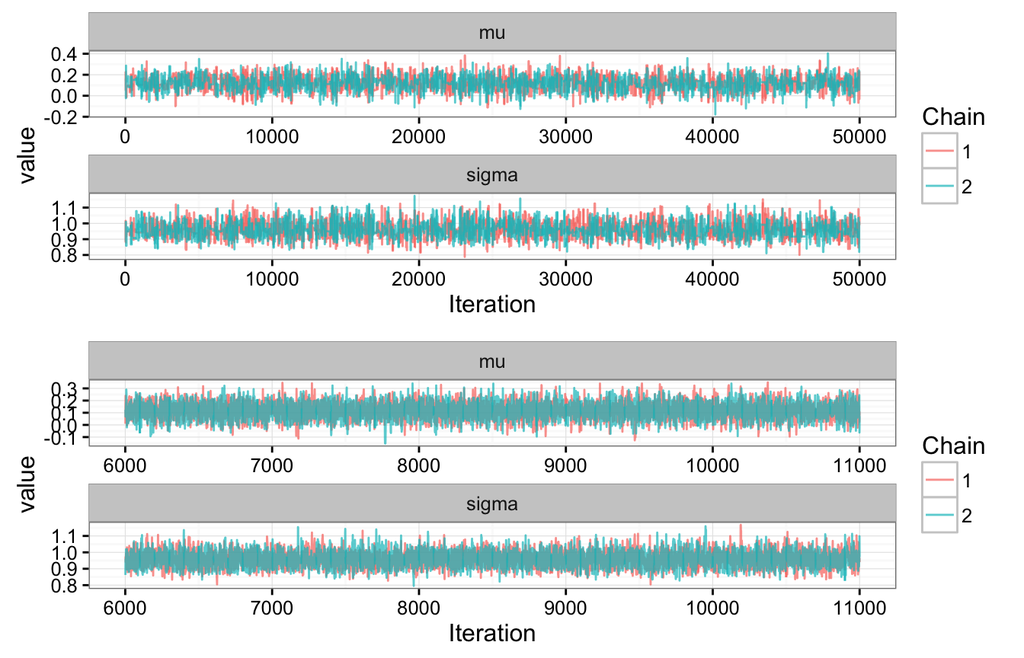

```r
grid.arrange(ggs_traceplot(ggs(samplesMH)) + theme(plot.background=element_blank()),
      ggs_traceplot(ggs(samplesJAGS)) + theme(plot.background=element_blank()))
```

## compare sample outputs

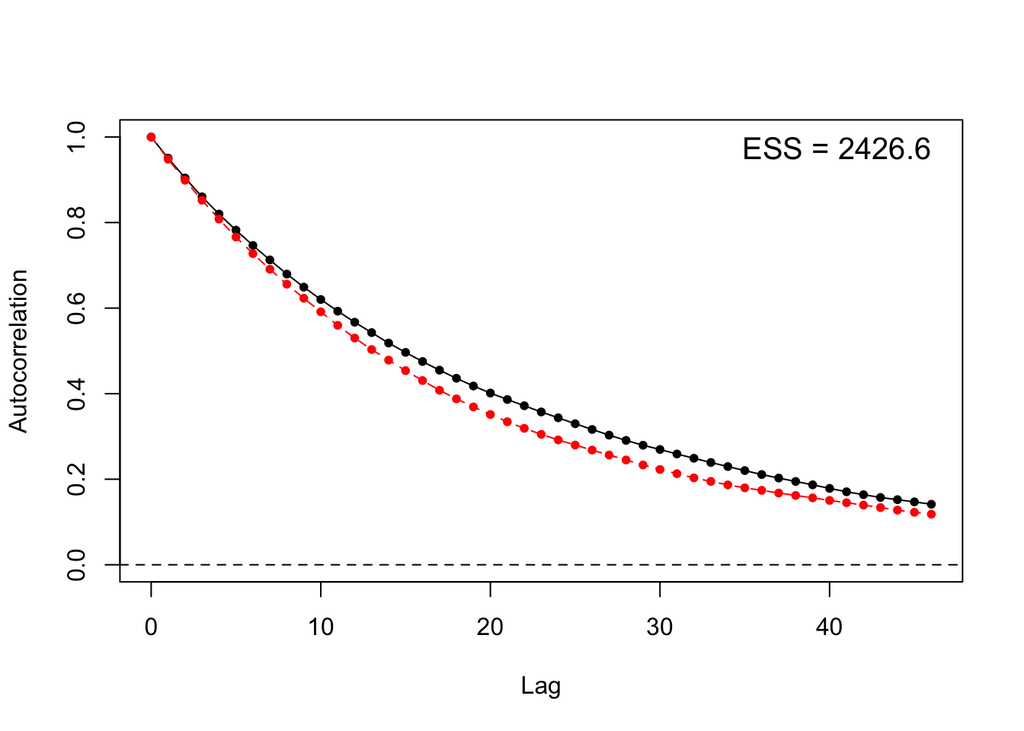

```r
# function from Kruschke, defined in 'DBDA2E-utilities.R'
DbdaAcfPlot(samplesMH) + theme(plot.background=element_blank())
```

## compare sample outputs

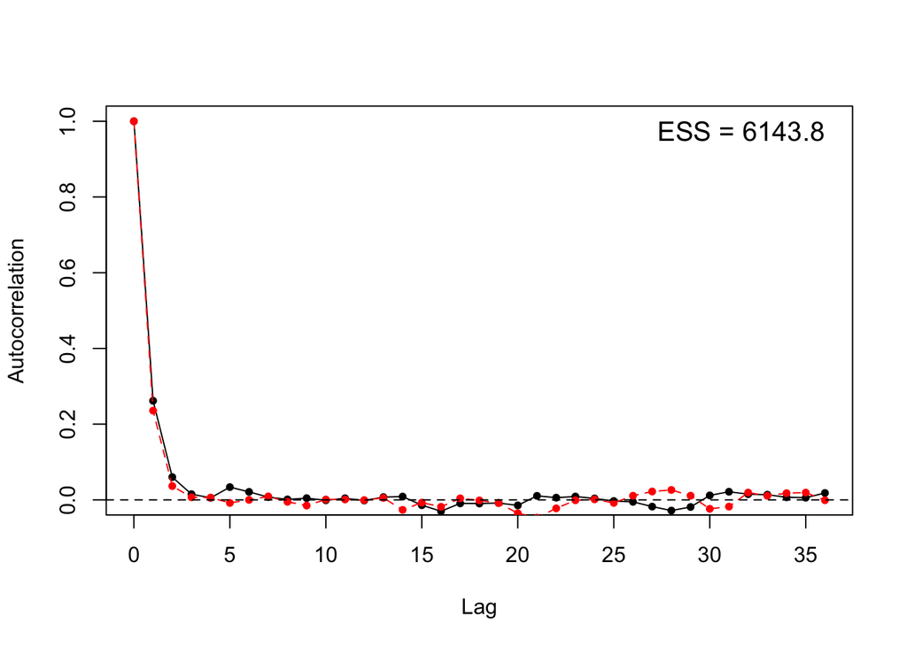

```r
# function from Kruschke, defined in 'DBDA2E-utilities.R'
DbdaAcfPlot(samplesJAGS) + theme(plot.background=element_blank())
```

## tips and tricks

## debugging

develop step by step & monitor each new intermediate variable

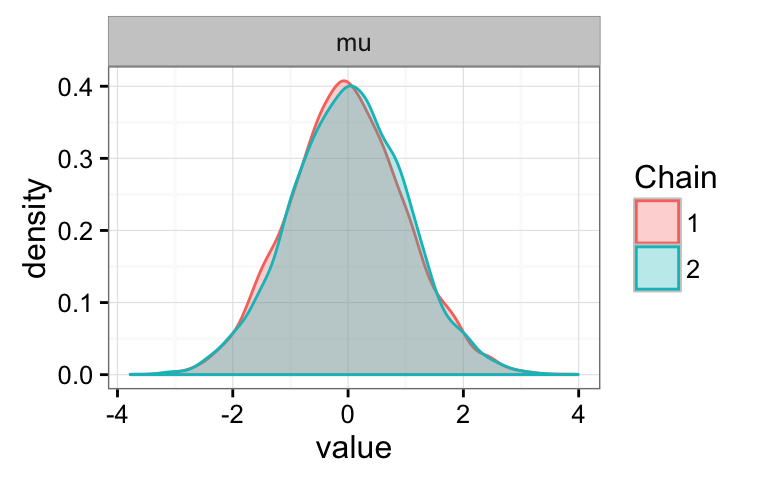

```r
modelString = "
model{
  mu ~ dnorm(0,1)
}"
jagsModel = jags.model(file = textConnection(modelString),
                       data = list(obs = fakeData),
                       n.chains = 2, n.adapt = 10)
update(jagsModel, n.iter = 10)
codaSamples = coda.samples(jagsModel, variable.names = c("mu"), n.iter = 5000)
ggs_density(ggs(codaSamples))
```

## prior and posterior predictive

```r
model{
  thetaPost ~ beta(1,1)
  thetaPrior ~ beta(1,1)
  # generate data from prior distribution
  priorPredictive ~ dbin(thetaPrior,n)
  # here `thetaPost` is conditioned on observed data!!
  kObs ~ dbin(thetaPost, n)
  # generate data from posterior
  posteriorPredictive ~ dbin(thetaPost, n)
}
```

prior predictive

\[ P(D) = \int P(\theta) \ P(D \mid \theta) \ \text{d}\theta \]

posterior predictive

\[ P(D \mid D') = \int P(\theta \mid D') \ P(D \mid \theta) \ \text{d}\theta \]

## conditioning

- boolean operations `x <= y`, `x != y`, `x || y` as usual (see manual)
- functions `ifelse`, `equals` and `step` for boolean conditioning

```r
model{
  flag ~ dbern(0.5)
  parameter1 = ifelse(flag, 0, -100)
  parameter2 = ifelse(flag, 1, 100)
}
```

## a problem

What is this model trying to achieve? And, why does it not work?

```r
model{
  flag ~ dbern(0.5)
  SOMEPDF = ifelse(flag, dnorm, dunif)
  parameter1 = ifelse(flag, 0, -100)
  parameter2 = ifelse(flag, 1, 100)
  for(i in 1:length(obs)){
    obs[i] ~ SOMEPDF(parameter1, parameter2)
  }
}
```

## solution

```r
data{
  for (i in 1:length(obs)){
    ones[i] = 1 # create a vector of ones
  }
}
model{
  flag ~ dbern(0.5)
  parameter1 = ifelse(flag, 0, -100)
  parameter2 = ifelse(flag, 1, 100)
  for(i in 1:length(obs)){
    theta[i] = ifelse(flag,
                      dnorm(obs[i],parameter1, parameter2),
                      dunif(obs[i],parameter1, parameter2))
    ones[i] ~ dbern(theta[i])
  }
}
```

## fini

## outlook

Friday

- 1st practice session

Tuesday

- more complex (interesting) models

## next class ::: we need you prepared!!

totally obligatory

- have installed on your laptop, newest versions of:
  - `R` and `JAGS` (optional and recommended: `RStudio`)
  - packages: `R2jags`, `rjags` and `runjags`
- obtain access to chapters 3 & 4 of [Lee & Wagenmakers](https://bayesmodels.com) (university library!)
  - download the [example code for JAGS](https://webfiles.uci.edu/mdlee/Code.zip)
  - make sure that you can execute the file `Code/ParameterEstimation/Binomial/Rate_1_jags.R`
    - hint: you may need to plan a rendevous with line 10 of this file